# R ve fyzické geografii: Základy kreslení grafů ve smyslu ggplot2

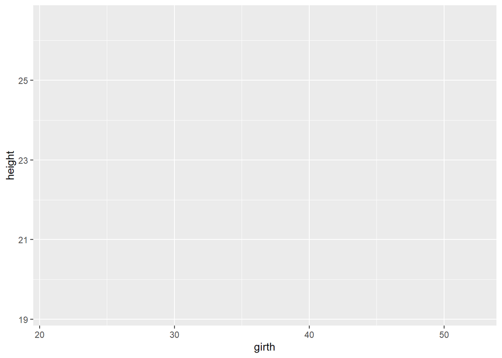

```r
# ta kreslí jen jakési plátno a očekává, že vyplníme dva důležité argumenty - data a mapping

# do argumentu data dodáváme vstupní tabulku
# argumentem mapping specifikujeme, co se bude vynášet na osy (používáme pomocníka aes(), z angl. 'aestetics')
ggplot(data = df2,
       mapping = (aes(x = girth,
                      y = height)
       )
)
```

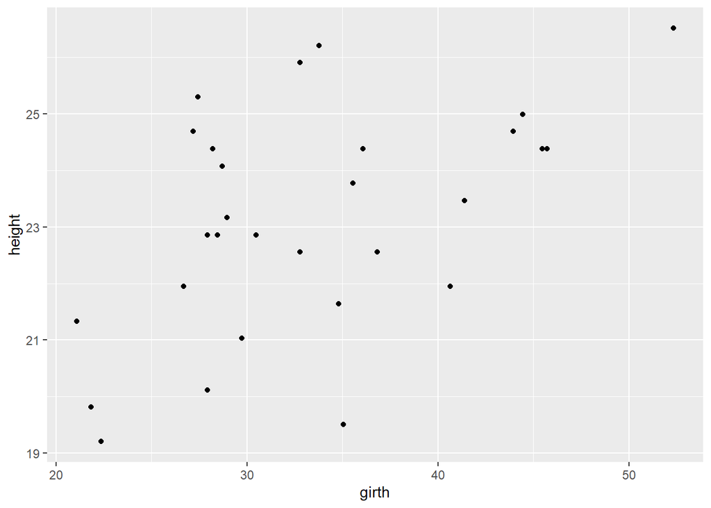

```r
# tím se zatím jen určí rozsahy os
# pořád ještě ale potřebujeme určit, jak se budou data kreslit
# k tomu slouží celá řada funkcí s názvy začínajícími na 'geom_', z nich v tomto případě je asi nejčastější geom_point() pro tzv. scatterplot (v Excelu známý pod pojmem XY bodový graf)
ggplot(df2, # protože argumenty data a mapping jsou jasné, lze jejich názvy vynechávat z důvodu ušetření psaní textu
       aes(x = girth,
           y = height)) + # pozor! vrstvíme operátorem + (nezaměňovat s pipem!)
  geom_point()
```

Vidíme, že můžeme hovořit o slabší linární závislosti. Existují i funkce, kterými můžeme data vyrovnat. Nejznámější je zřejmě regresní přímka, jejíž parametry získáváme lineárním modelem, v `R` tedy funkcí `lm()`. Zkusme si tuto přímku vykreslit.

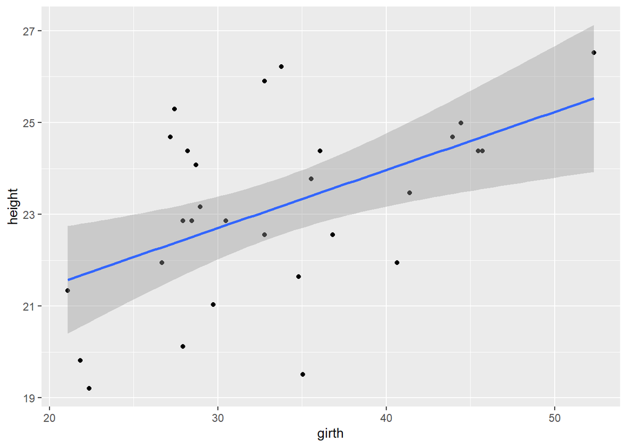

```r
df2 |> # i takto lze tabulku dodat funkci ggplot() coby argument data
  ggplot(aes(x = girth,
             y = height)) +
  geom_point() +
  geom_smooth(method = "lm")
```

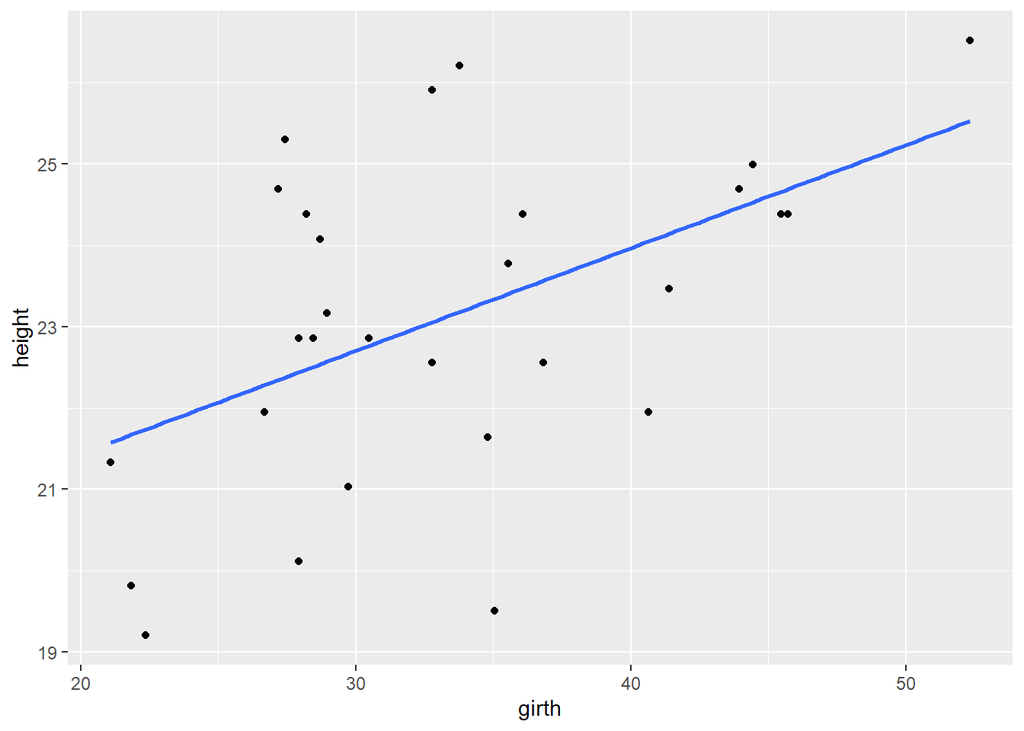

```r
# pásy kolem souvisejí se standardní chybou (standard error, se)
# lze je odstranit takto
df2 |>
  ggplot(aes(x = girth,
             y = height)) +
  geom_point() +
  geom_smooth(method = "lm",
              se = F) # FALSE lze zkracovat na F
```

Bylo by ale ještě vhodné upravit si nadpis a popisky os, příp. dodat informaci o zdroji dat.

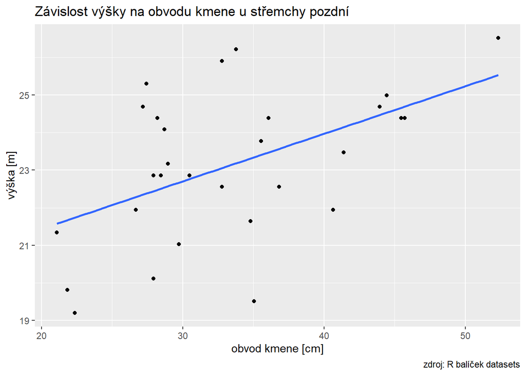

```r
# k tomuto obecně slouží funkce labs()
df2 |>
  ggplot(aes(x = girth,
             y = height)) +
  geom_point() +
  geom_smooth(method = "lm",
              se = F) +
  labs(title = "Závislost výšky na obvodu kmene u střemchy pozdní",
       x = "obvod kmene [cm]",
       y = "výška [m]",
       caption = "zdroj: R balíček datasets")
```

Funkce začínající názvem ‘`theme_`’ přenastavují obecný vzhled grafu.

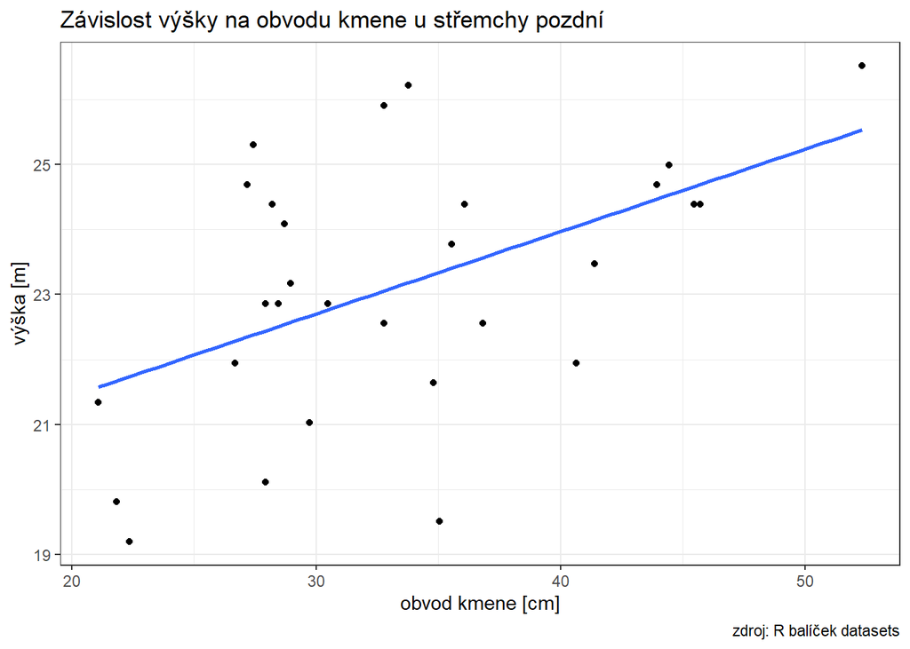

```r
df2 |>
  ggplot(aes(x = girth,
             y = height)) +
  geom_point() +
  geom_smooth(method = "lm",
              se = F) +
  labs(title = "Závislost výšky na obvodu kmene u střemchy pozdní",
       x = "obvod kmene [cm]",
       y = "výška [m]",
       caption = "zdroj: R balíček datasets") +
  theme_bw() # pro černobílý finální vzhled
```

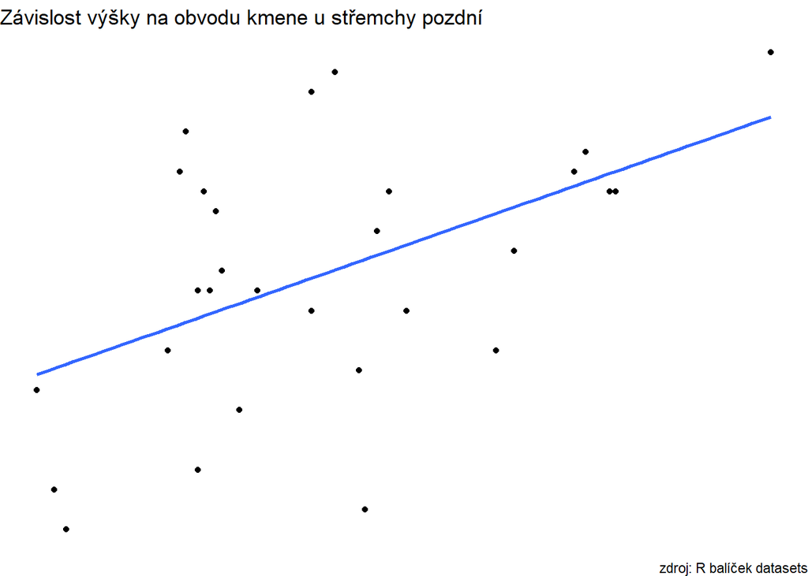

```r
# avšak pozadí lze úplně vynechat
# k čemu by se to mohlo hodit?
df2 |>
  ggplot(aes(x = girth,
             y = height)) +
  geom_point() +
  geom_smooth(method = "lm",
              se = F) +
  labs(title = "Závislost výšky na obvodu kmene u střemchy pozdní",
       x = "obvod kmene [cm]",
       y = "výška [m]",
       caption = "zdroj: R balíček datasets") +
  theme_void()
```

Na závěr obecného kreslení ukažme, že lze grafy výhodně kreslit i z tabulek s jednotkami (nemusíme je zahazovat funkcí `drop_units()`. Musíme ale napřed mít načteny balíčky `units` a `ggforce`, což již od začátku máme.

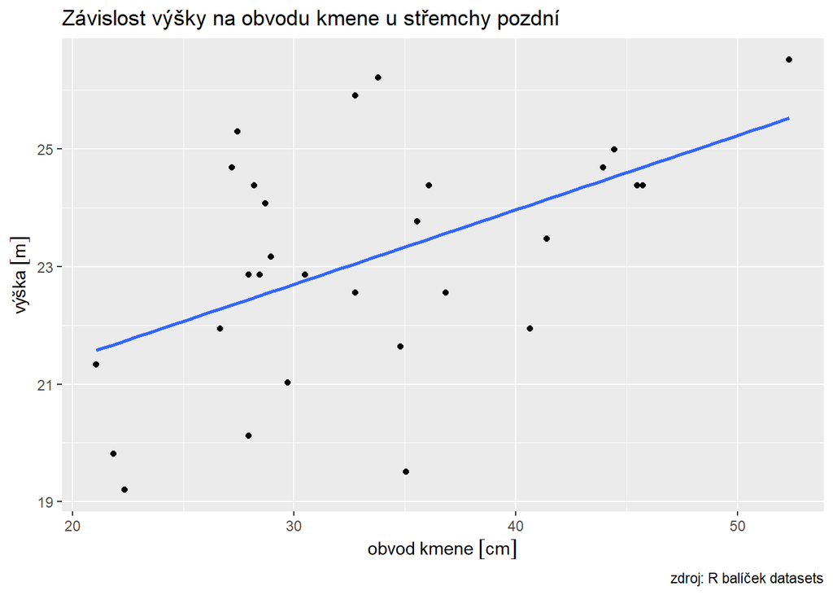

```r
# vycházíme tedy rovnou z tabulky v objektu 'df', která obsahuje jednotky v jednotlivých funkcích
df |>
  ggplot(aes(x = girth,
             y = height)) +
  geom_point() +
  geom_smooth(method = "lm",
              se = F) +
  labs(title = "Závislost výšky na obvodu kmene u střemchy pozdní",
       x = "obvod kmene",
       y = "výška",
       caption = "zdroj: R balíček datasets")
```

Výhodou je i fakt, že ve funkci `labs()` stačí pak přejmenovat jen proměnné, abychom měli např. správné české názvy u os, a nemusíme se zdržovat s psaním jednotek[^4]. Ty jsou za názvy proměnných dodány automaticky.

## Role dalších argumentů v pomocné funkci aes()

Existují argumenty, které můžeme, ale také nemusíme vkládat do pomocné funkce `aes()`. Když je nevložíme do funkce `aes()` a upřesňujeme je mimo ni, většinou to je z důvodu, že vše chceme vykeslit stejně. Když jsou naopak tyto argumenty součástí funkce `aes()`, mění se jejich chování v závislosti na datech (nějaké proměnné), tj. respektují určité měřítko, které lze pak také nastavit.

Mezi tyto argumenty např. patří `color` (často zkracujeme na `col`), `fill`, `size` (ale také `linewidth`, `linetype` apod).

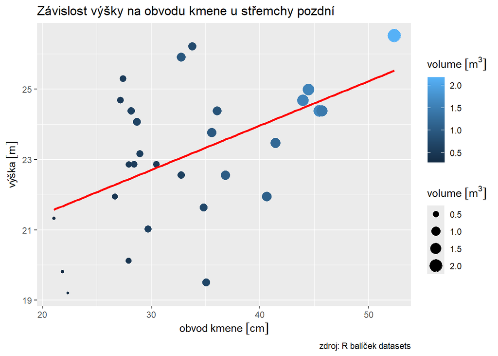

```r
# zde již tedy využijeme i třetí proměnnou - volume
df |>
  ggplot(aes(x = girth,
             y = height)) +
  geom_point(aes(size = volume,  # kromě globálního nastavení v ggplot() lze aes() ladit lokálně v každé geometrické funkci (tím se globální nastavení přepisuje)
                 col = volume)) + # stejnou proměnnou lze použít vícekrát
  geom_smooth(method = "lm",
              se = F,
              col = "red") + # tady se vlastně celá přímka kreslí červeně
  labs(title = "Závislost výšky na obvodu kmene u střemchy pozdní",
       x = "obvod kmene",
       y = "výška",
       caption = "zdroj: R balíček datasets")
```

## Jiné ‘geom_’ funkce

Zkusme dále kreslit např. histogramy nebo hustotu.

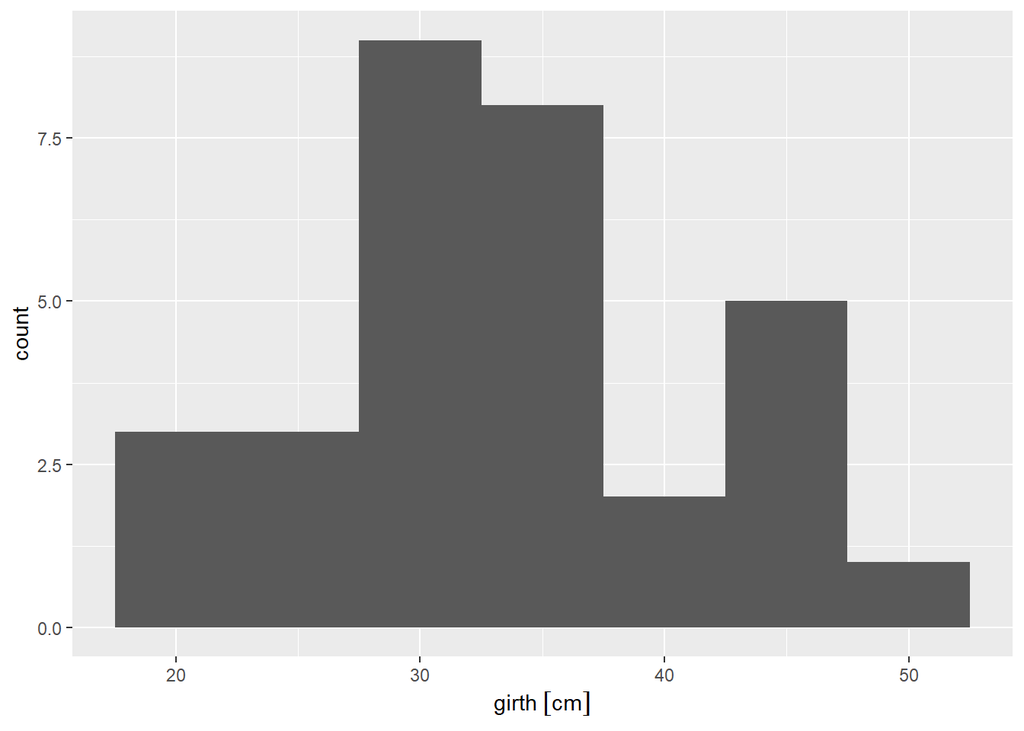

```r
# u histogramu je zásadním argument binwidth (nebo bins), kterým určujeme šířku intervalu (nebo počet intervalů) - zkuste přenastavovat
df |>
  ggplot(aes(x = girth)) + # zde stačí zadávat jen jednu souřadnici
  geom_histogram(binwidth = 5)
```

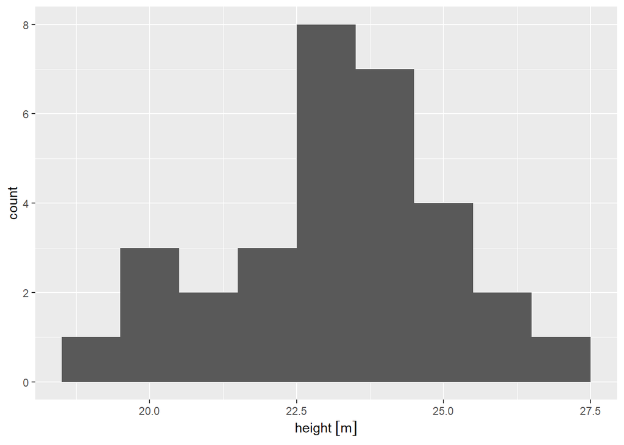

```r
df |>
  ggplot(aes(x = height)) +
  geom_histogram(binwidth = 1)
```

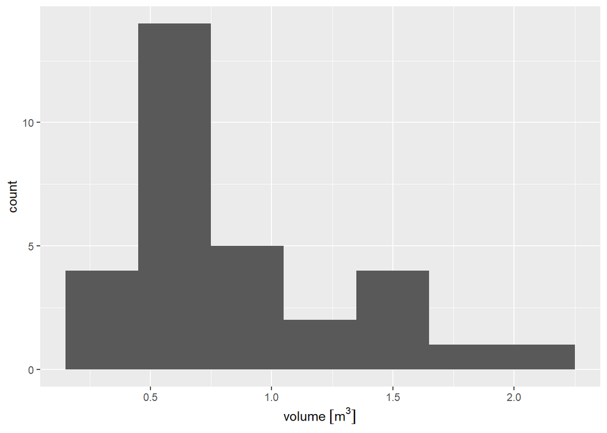

```r
df |>
  ggplot(aes(x = volume)) +
  geom_histogram(binwidth = 0.3)
```

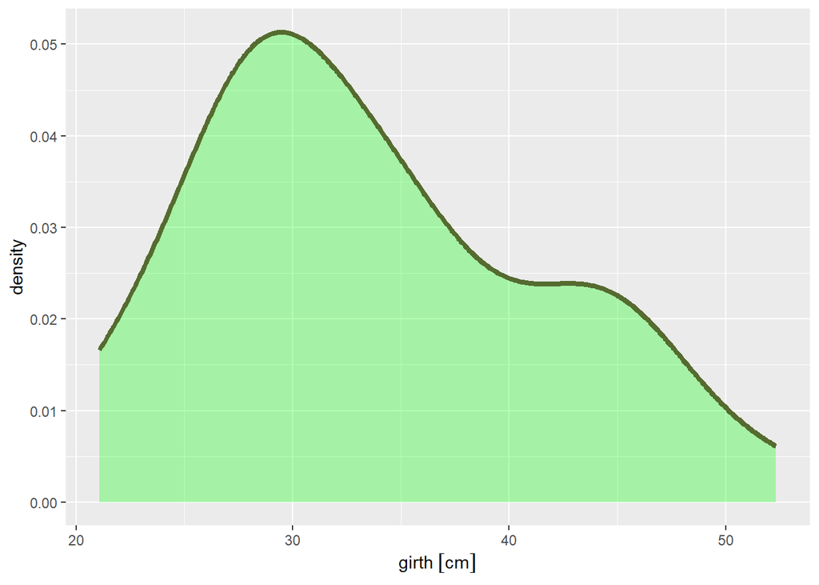

```r
# následuje příklad kreslení hustoty rozdělení proměnné 'obvod kmene'
# zde navíc ve funkci geom_density() demonstrujeme psaní argumentů mimo funkci aes()
df |>
  ggplot(aes(x = girth)) +
  geom_density(col = "darkolivegreen",
               linewidth = 1.5,
               fill = "green", # může pomoci i výplň
               alpha = 0.3) # takto nastavujeme průhlednost
```

```r
# zkuste i pro ostatní proměnné
```

Kategorické proměnné v tabulce nemáme, mají však zajímavou roli při kreslení grafů, jako jsou boxploty (krabicové grafy), sloupcové grafy nebo dokonce tzv. facety (viz kap. 1 v knize Wickham, Çetinkaya-Rundel, Grolemund 2023).

Za využití pivotingu tabulek si můžeme naší tabulku převést na dlouhý formát a demonstrovat např. konstrukci boxplotu. Protože každá proměnná má trochu jiné měřítko, před kreslením budeme standardizovat. Pro demonstraci funkcí zde využijeme tabulku v objektu `df2` (tedy bez jednotek)[^5].

```r
# funkce group_by() má značný význam, pokud něco chceme počítat po skupinách, zde proměnných
dfl <- df2 |>
  pivot_longer(cols = everything()) |>
  group_by(name) |>
  mutate(value = (value - mean(value)) / sd(value)) # funkce mutate() je citlivá na grupování, a tedy vhodná na standardizaci odečtením průměru a podělením tohoto výsledku směrodatnou odchylkou (vše po skupinách)

# podíváme se na začátek výsledku
# povšimněte si i uvedení počtu skupin na začátku tisku tabulky v konzoli
dfl
```

```
# A tibble: 93 × 2
# Groups:   name [3]
   name    value
   <chr>   <dbl>
 1 girth  -1.58
 2 height -0.942
 3 volume -1.21
 4 girth  -1.48
 5 height -1.73
 6 volume -1.21
 7 girth  -1.42
 8 height -2.04
 9 volume -1.21
10 girth  -0.876
# ℹ 83 more rows
```

```r
dfl |>
  class()
```

```
[1] "grouped_df" "tbl_df"     "tbl"        "data.frame"
```

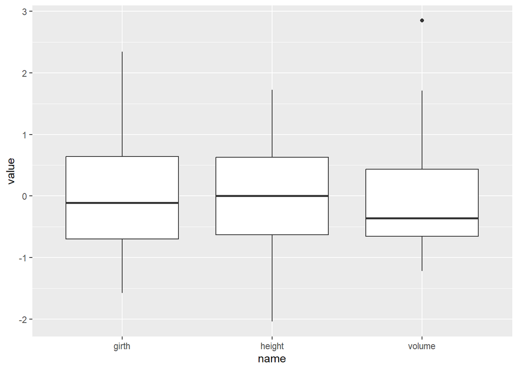

```r
# a už můžeme kreslit boxplot
dfl |>
  ggplot(aes(x = name,
             y = value)) +
  geom_boxplot()
```

## Ukládání grafů do souboru

Pracně vyhotovené grafy je vhodné uložit. Existuje sice možnost si uložit grafy po jednom tlačítkem Export v kartě Plots, ale je lepší se hned naučit ukládat soubory programaticky (z příkazové řádky). Má to hned několik výhod – můžeme uložit rychle několik grafů najednou do svých vlastních souborů. Lze si tím snadno hlídat rozměry (např. stránky A5) a tzv. drivery pro různé typy souborů. Avšak našlo by se jistě i více výhod např. po prozkoumání síly tzv. funkcionálního programování a “lepení” textových řetězců.

Zásadní pro ukládání grafů vytvořených funkcemi balíčku `ggplot2` je funkce `ggsave()`. Tato funkce standardně ukládá poslední graf vykreslený v kartě Plots, ale, co se bude kreslit, je možné si pohlídat uložením grafu do objektu a specifikováním argumentu `plot`.

Přiřaďme si nejprve náš krabicový graf do objektu a pak z tohoto objektu uložme graf do PDF souboru specifikováním přípony .pdf v názvu souboru.

```r
# nejprve přiřazení k objektu
p1 <- dfl |>
  ggplot(aes(x = name,
             y = value)) +
  geom_boxplot()

# teď uložení z tohoto objektu
# nastavme např. velikost A6
# rozlišení necháme stejné
ggsave("obrazky/boxplot.pdf",
       width = 148,
       height = 105,
       units = "mm", # i tohle hlídání si jednotek může být velkou výhodou funkce ggsave() oproti ukládání tlačítkem Export
       plot = p1)
```

## Reference

WICKHAM, H., ÇETINKAYA-RUNDEL, M., GROLEMUND, G. (2023): R for Data Science: Import, Tidy, Transform, Visualize, and Model Data. O’Reilly Media, Inc, Sebastopol, CA.

## Poznámky pod čarou

[^1]: Viz např. https://www.youtube.com/watch?v=wqOme7xsZvs nebo https://youtu.be/JdH8wwBZANw?si=9U2hSzXywCUQMgW0.
[^2]: Písmena ‘gg’ na začátku názvu balíčku znamenají *grammar of graphics*, tedy ucelenou gramatiku, na základě které lze poměrně rychle stavět dále.
[^3]: Tedy pokud již máme pro následující příklad nainstalovaný balíček `janitor`, jehož funkci `clean_names()` hodláme využít v konstruktu se dvěma dvojtečkami `::`.
[^4]: Někdy psaní v exponenciálním tvaru dokáže dost potrápit.
[^5]: Lze to provést i s tabulkou v objektu `df` s jednotkami, načtený balíček `units` to umožňuje. Výsledkem standardizace by však byly proměnné s jednotkami `[1]`, protože se původní jednotky dělí. Ale pracovat s nimi dále by bylo zřejmě zbytečné.